# Predicting Product Returns Using K-Nearest Neighbors (KNN)

[figure not shown]

### Why predicting returns?

- Insights into product quality issues, customer preferences, areas for improvement in the supply chain or product offerings, etc.
- More efficient inventory management by taking returned products into account.
- Better planning of transportation capacities
- ...

## Data exploration and preprocessing

Let's load a dataset of transaction records.

```python
import pandas as pd

df_returns = pd.read_csv("Data/product_returns.csv")
df_returns.head()
```

|  | Transaction_ID | Customer_ID | Product_Category | Location | Order_Size | Price | Coupon | Return_Last_Year | Total_Purchase_Last_Year | returned |
| --- | --- | --- | --- | --- | --- | --- | --- | --- | --- | --- |
| 0 | TX5170 | c5683 | Home | rural | 4 | 46.34 | yes | 0 | 599.76 | 0 |
| 1 | TX2462 | c3328 | Sports | rural | 6 | 46.29 | no | 0 | 541.54 | 0 |
| 2 | TX9673 | c2573 | Beauty | city | 5 | 48.47 | yes | 0 | 476.93 | 0 |
| 3 | TX7125 | c8932 | Beauty | rural | 4 | 54.82 | no | 0 | 702.72 | 0 |
| 4 | TX6799 | c3956 | Electronics | rural | 5 | 53.43 | yes | 0 | 553.99 | 0 |

Target variable $y$: **returned**

- 1 means that the product is returned (positive), 0 means not returned (negative)

Features ($X$):

- **Transaction_ID**: Identifier of the order to which the product belong
- **Customer_ID** Unique identifier of the customer who made the purchase
- **Product_Category**: The category of the product
- **Location**: Location of the customer
- **Order_Size**: Number of items included in the order
- **Price**: Price of the product
- **Coupon**: Is a coupon used for the product?
- **Return_Last_Year**: How many returns were made by the same customer in the past year
- **Total_Purchase_Last_Year**: Total dollar amount of the same customer's spending in the past year

**Data cleaning**: As usual, one needs to check missing values, replications, outliers, etc. (Skipped here.)

**Data exploration**: Let's check the distribution of the target variable (and other variables)

```python
print(df_returns['returned'].value_counts())
print(df_returns['Product_Category'].value_counts())
```

```
returned
0    2455
1    2431
Name: count, dtype: int64
Product_Category
Books          1098
Home           1066
Fashion        1036
Electronics     985
Sports          395
Beauty          306
Name: count, dtype: int64
```

The class labels are balanced. So we will not perform over-/under-sampling.

Let's perform **one-hot encoding** for

- Product_Category
- Location
- Coupon

```python
df_returns_encoded = pd.get_dummies(df_returns,columns=['Product_Category','Location','Coupon'],drop_first=True,dtype=int)

df_returns_encoded.head()
```

|  | Transaction_ID | Customer_ID | Order_Size | Price | Return_Last_Year | Total_Purchase_Last_Year | returned | Product_Category_Books | Product_Category_Electronics | Product_Category_Fashion | Product_Category_Home | Product_Category_Sports | Location_rural | Coupon_yes |
| --- | --- | --- | --- | --- | --- | --- | --- | --- | --- | --- | --- | --- | --- | --- |
| 0 | TX5170 | c5683 | 4 | 46.34 | 0 | 599.76 | 0 | 0 | 0 | 0 | 1 | 0 | 1 | 1 |
| 1 | TX2462 | c3328 | 6 | 46.29 | 0 | 541.54 | 0 | 0 | 0 | 0 | 0 | 1 | 1 | 0 |
| 2 | TX9673 | c2573 | 5 | 48.47 | 0 | 476.93 | 0 | 0 | 0 | 0 | 0 | 0 | 0 | 1 |
| 3 | TX7125 | c8932 | 4 | 54.82 | 0 | 702.72 | 0 | 0 | 0 | 0 | 0 | 0 | 1 | 0 |
| 4 | TX6799 | c3956 | 5 | 53.43 | 0 | 553.99 | 0 | 0 | 1 | 0 | 0 | 0 | 1 | 1 |

We will:

- seperate the target variable and the feature variables
- split the dataset into a training set and a testing set.

```python
from sklearn.model_selection import train_test_split

y = df_returns_encoded['returned']
X = df_returns_encoded.drop(['returned','Transaction_ID','Customer_ID'],axis=1)
```

**Feature scaling** for KNN is important, because KNN uses distance metrics like Euclidean distance to find the nearest neighbors, wbich is sensitive to scale.

For example,

- The variable **Order_Size** ranges from 1 to 6
- The variable **Price** ranges from 17 to 88

The latter has a much larger scale, thus contributing more to the calcualtion of distances. As a result, it could have an (unfairly) larger influence on the result.

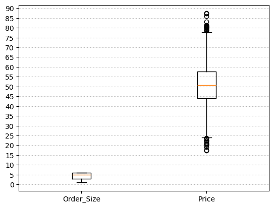

```python
import matplotlib.pyplot as plt
plt.boxplot([df_returns['Order_Size'],df_returns['Price']])
plt.xticks([1,2],['Order_Size','Price'])
plt.yticks(range(0,95,5))
plt.grid(axis='y',linestyle=':')
plt.show()
```

So we will scale the features.

```python
from sklearn.preprocessing import RobustScaler
scaler = RobustScaler()
X_scaled = scaler.fit_transform(X)
X_scaled
```

```
array([[-0.33333333, -0.32624376,  0.        , ...,  0.        ,
         1.        ,  1.        ],
       [ 0.33333333, -0.32994267,  0.        , ...,  1.        ,
         1.        ,  0.        ],
       [ 0.        , -0.16867024,  0.        , ...,  0.        ,
         0.        ,  1.        ],
       ...,
       [ 0.33333333, -0.94396153,  1.66666667, ...,  0.        ,
         0.        ,  0.        ],
       [-0.33333333,  0.37358979,  0.        , ...,  0.        ,
         0.        ,  0.        ],
       [-0.66666667,  0.30405031,  1.66666667, ...,  0.        ,
         0.        ,  0.        ]])
```

```python
X_scaled = pd.DataFrame(X_scaled,columns=X.columns)
X_scaled.head()
```

|  | Order_Size | Price | Return_Last_Year | Total_Purchase_Last_Year | Product_Category_Books | Product_Category_Electronics | Product_Category_Fashion | Product_Category_Home | Product_Category_Sports | Location_rural | Coupon_yes |
| --- | --- | --- | --- | --- | --- | --- | --- | --- | --- | --- | --- |
| 0 | -0.333333 | -0.326244 | 0.0 | 0.215894 | 0.0 | 0.0 | 0.0 | 1.0 | 0.0 | 1.0 | 1.0 |
| 1 | 0.333333 | -0.329943 | 0.0 | -0.160885 | 0.0 | 0.0 | 0.0 | 0.0 | 1.0 | 1.0 | 0.0 |
| 2 | 0.000000 | -0.168670 | 0.0 | -0.579019 | 0.0 | 0.0 | 0.0 | 0.0 | 0.0 | 0.0 | 1.0 |
| 3 | -0.333333 | 0.301091 | 0.0 | 0.882216 | 0.0 | 0.0 | 0.0 | 0.0 | 0.0 | 1.0 | 0.0 |
| 4 | 0.000000 | 0.198262 | 0.0 | -0.080313 | 0.0 | 1.0 | 0.0 | 0.0 | 0.0 | 1.0 | 1.0 |

Let's check again the scales of **Order_Size** and **Price**

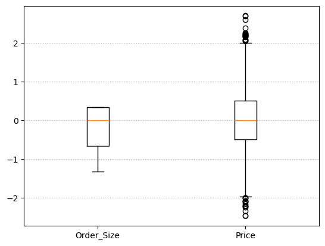

```python
import matplotlib.pyplot as plt
plt.boxplot([X_scaled['Order_Size'],X_scaled['Price']])
plt.xticks([1,2],['Order_Size','Price'])
plt.grid(axis='y',linestyle=':')
plt.show()
```

We can now do the train test split.

```python
X_train,X_test,y_train,y_test = train_test_split(X_scaled,y,test_size=0.2,random_state=10,stratify=y)
```

### Building and training a KNN model

To build a KNN model, we can use the `KNeighborsClassifier()` function in `sklearn`.

Note that we need to specify the **number of nearest neighbors** to use for prediction using the `n_neighbors=` argument.

```python
from sklearn.neighbors import KNeighborsClassifier

knn_model = KNeighborsClassifier(n_neighbors=3)
knn_model.fit(X_train,y_train)
```

```
KNeighborsClassifier(n_neighbors=3)
```

### Predicting for a new data point

Let's predict for the following new data point.

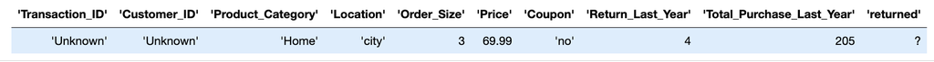

```python
data_new = pd.DataFrame([['Unknown', 'Unknown', 'Home','city',3, 69.99,'no',4,205,0]],
                        columns=df_returns.columns)

data_new
```

|  | Transaction_ID | Customer_ID | Product_Category | Location | Order_Size | Price | Coupon | Return_Last_Year | Total_Purchase_Last_Year | returned |
| --- | --- | --- | --- | --- | --- | --- | --- | --- | --- | --- |
| 0 | Unknown | Unknown | Home | city | 3 | 69.99 | no | 4 | 205 | 0 |

We will need to **encode** and **scale** the data point!

How do we encode the new data point?

We can append the new data point to `df_returns`.

```python
df_with_new_data = pd.concat([df_returns,data_new],axis=0,ignore_index=True)
df_with_new_data.tail()
```

|  | Transaction_ID | Customer_ID | Product_Category | Location | Order_Size | Price | Coupon | Return_Last_Year | Total_Purchase_Last_Year | returned |
| --- | --- | --- | --- | --- | --- | --- | --- | --- | --- | --- |
| 4882 | TX2554 | c7562 | Electronics | rural | 5 | 57.43 | no | 9 | 648.47 | 1 |
| 4883 | TX7068 | c3129 | Electronics | city | 6 | 37.99 | no | 5 | 486.94 | 1 |
| 4884 | TX819 | c8322 | Electronics | city | 4 | 55.80 | no | 0 | 659.09 | 1 |
| 4885 | TX7529 | c9526 | Home | city | 3 | 54.86 | no | 5 | 671.92 | 1 |
| 4886 | Unknown | Unknown | Home | city | 3 | 69.99 | no | 4 | 205.00 | 0 |

Note that:

- the argument `axis=0` in `pd.concat()` will combine the two DataFrame vertically (along axis 0), effectively appending the new data point to the end of the original dataset `df_returns`, and
- `ignore_index=True` will reset the indexes after combining the two DataFrames

Now let's encode the combined dataset.

```python
df_with_new_data_enc = pd.get_dummies(df_with_new_data,columns=['Product_Category','Location','Coupon'],
                                      drop_first=True, dtype=int)
df_new_data = df_with_new_data_enc.tail(1)
df_new_data
```

|  | Transaction_ID | Customer_ID | Order_Size | Price | Return_Last_Year | Total_Purchase_Last_Year | returned | Product_Category_Books | Product_Category_Electronics | Product_Category_Fashion | Product_Category_Home | Product_Category_Sports | Location_rural | Coupon_yes |
| --- | --- | --- | --- | --- | --- | --- | --- | --- | --- | --- | --- | --- | --- | --- |
| 4886 | Unknown | Unknown | 3 | 69.99 | 4 | 205.0 | 0 | 0 | 0 | 0 | 1 | 0 | 0 | 0 |

```python
df_returns_encoded.head(1)
```

|  | Transaction_ID | Customer_ID | Order_Size | Price | Return_Last_Year | Total_Purchase_Last_Year | returned | Product_Category_Books | Product_Category_Electronics | Product_Category_Fashion | Product_Category_Home | Product_Category_Sports | Location_rural | Coupon_yes |
| --- | --- | --- | --- | --- | --- | --- | --- | --- | --- | --- | --- | --- | --- | --- |
| 0 | TX5170 | c5683 | 4 | 46.34 | 0 | 599.76 | 0 | 0 | 0 | 0 | 1 | 0 | 1 | 1 |

As we can see by comparing with `df_returns_encoded`, the new data point is encoded into a row with the same columns.

We still need to scale the new datapoint in the *same way* as the original feature data `X` was scaled.

```python
X_new = df_new_data.drop(['returned','Transaction_ID','Customer_ID'],axis=1)
X_new_scaled = pd.DataFrame(scaler.transform(X_new),columns=X.columns)

knn_model.predict(X_new_scaled)
```

```
array([1])
```

So the model predicts that the purchase will be returned.

### Model performance

We will predict on the test dataset and compare the predictions with the observations.

- Import the performance metrics.
- Predict on the test data.
- Get the performance measures.

```python
from sklearn.metrics import confusion_matrix, classification_report, accuracy_score, roc_auc_score
y_pred = knn_model.predict(X_test)
y_prob_pred = knn_model.predict_proba(X_test)
cm = confusion_matrix(y_test,y_pred)
cr = classification_report(y_test,y_pred)
print(cm)
print(cr)
```

```
[[374 117]
 [134 353]]
              precision    recall  f1-score   support

           0       0.74      0.76      0.75       491
           1       0.75      0.72      0.74       487

    accuracy                           0.74       978
   macro avg       0.74      0.74      0.74       978
weighted avg       0.74      0.74      0.74       978
```

### Cross validation

Cross-validation is a technique used to assess the performance and generalizability of a model by dividing the dataset into multiple subsets.

Process of the k-fold cross validation:

- The data is split into $k$ equal parts (called **folds**) for $k$-fold cross-validation.
- The model is trained on $k-1$ folds and tested on the remaining fold.
- This process is repeated $k$ times, each time using a different fold as the test set.

**Result**: The performance metrics (e.g., accuracy, precision, AUC) from each fold are averaged to provide a more reliable estimate of the model's performance.

Example: 5-fold cross validation.

- First, divide the dataset into 5 equal folds
- Each fold gets a turn to act as the testing dataset; see the following illustrations

[figure not shown]

#### First train-test split

[figure not shown]

#### Second train-test split

[figure not shown]

#### Third train-test split

[figure not shown]

#### Fourth train-test split

[figure not shown]

#### Fifth train-test split

[figure not shown]

Why cross validation?

- Ensures that the model's performance is **evaluated on multiple test sets**, giving a better indication of how it will perform on unseen data.
- **Makes the most** of a limited dataset by using all data points for both training and testing across different iterations.

To implement cross validation, we first need to define a **cross-validation strategy**.

The `StratifiedKFold()` function from the module `model_selection` in `sklearn` defines a cross-validation strategy.

- 'Stratified' means that the fraction of a class label in each fold are the same.
- It use the following arguments:
  - `n_splits=` specifies the number of folds
  - `shuffle=True` will shuffle the rows before splitting, effectively randomize the split
  - `random_state=` specifies the random state/see for shuffling, ensuring reproducibility

```python
from sklearn.model_selection import cross_val_score, StratifiedKFold
stratified_kfold = StratifiedKFold(n_splits=5, shuffle=True, random_state=10)
```

The function `cross_val_score()` calculates the performance score (accuracy, precision, auc score, etc.) for all the train-test splits in a cross validation procedure.

- We need to provide the following argments:
  - The learning model (linear regression, logistic regression, KNN, etc.)
  - features (X) and target (y); the function `cross_val_score()` will do the train-test split on them
  - `cv=` specifies the cross-validation strategy
  - `scoring=` specifies the performance scores to use.

```python
scores = cross_val_score(knn_model, X_scaled, y, cv=stratified_kfold,scoring='roc_auc')
print(scores)
scores.mean()
```

```
[0.78192893 0.77583122 0.77545825 0.78518477 0.79947701]
```

```
0.7835760335380698
```

For classifications, we can use the following scores:

- 'accuracy': Proportion of correctly classified samples.
- 'precision': Precision score (use 'precision_macro', 'precision_weighted', etc. for different averaging methods)
- 'recall': Recall score (use 'recall_macro', 'recall_weighted', etc. )
- 'f1': F1 score (use 'f1_macro', 'f1_weighted', etc.)
- 'roc_auc': Area under the Receiver Operating Characteristic curve (useful for binary classification problems)

### Choosing the number of neighbors based on cross-validation

The number of neighbors to use in KNN, `n_neighbors`, is a **hyperparameter**, as it is not chosen during the training/fitting process.

`GridSearchCV` in `scikit-learn.model_selection` is a powerful tool used to perform hyperparameter tuning for machine learning models.

`GridSearchCV` work as follows:

1. **Define a Range of Hyperparameters**: We specify a dictionary where the keys are the hyperparameters you want to tune, and the values are the lists of values to try.
2. It **trains and evaluates the model** for *every combination of hyperparameters* using **cross-validation**, with respect to a given performance score.

```python
# Import the GridSearchCV function
from sklearn.model_selection import GridSearchCV

# Define the parameter grid. We will only tune 'n_neighbors' here.
param_grid = {'n_neighbors': range(1, 102, 4)}

# Define the learning model. We use KNN here
knn = KNeighborsClassifier()

# Define the grid search with cross-validation. Note that 'stratified_kfold' is defined earlier.
# By default, scoring='accuracy' is used; but we may change it.
grid_search = GridSearchCV(knn, param_grid, cv=stratified_kfold,scoring='roc_auc')

# Fit the grid_search. We need to provide the features (X) and the target (y) before splitting

grid_search.fit(X_scaled, y)
```

```
GridSearchCV(cv=StratifiedKFold(n_splits=5, random_state=10, shuffle=True),
             estimator=KNeighborsClassifier(),
             param_grid={'n_neighbors': range(1, 102, 4)}, scoring='roc_auc')
```

In the above, we searched for the best value of `n_neighbors` over the range $1,5,9,13,...,101$.

During the fitting process, the model calculates and compares the **average score under cross-validation** for each value in the range.

After fitting, the attritues `.best_params_` and `.best_score_` of the `GridSearchCV` object will give us the best parameter value for maximizing the score, and the corresponding best score.

```python
n_nbs_best = grid_search.best_params_['n_neighbors']

print(f"Best n_neighbors is {n_nbs_best}, best auc score is {grid_search.best_score_}")
```

```
Best n_neighbors is 17, best auc score is 0.8214252089447542
```

Now that we find the best number of neighbors, we can rebuild the KNN model with that number.

```python
knn = KNeighborsClassifier(n_neighbors=n_nbs_best)

scores = cross_val_score(knn, X_scaled, y, cv=stratified_kfold, scoring='roc_auc')
print(scores)
scores.mean()
```

```
[0.83185428 0.81475824 0.79793694 0.82708716 0.83548943]
```

```
0.8214252089447542
```

One may use `knn.predict()` and `knn.predict_proba()` to make prediction.